# Analysis and Prediction of Movie Performance

## 19BCE1349 Anish Hemant There

## 19BCE1260 Sahil Arora

## 19BCE1366 Puvvadi Harsha Vardhan

The question of what makes a movie good has been asked for a while now. Quantifying the parameters on which a movie’s performance is one of the ways to predict how a movie would perform amongst others. Movie reviews are important because if they have a significant effect on the consumer thought processes, they can be used not only as a marketing tool by film production studios, but also as a predictor as to how a film will perform financially. We heavily rely on other people’s opinion and analysis to choose which movie to watch. The parameters on which the movie’s performance rely upon is dependent on duration of the movie, the critics reviews, the genre the movie is based on etc. We aim to analyze the data and find the parameters which affect a movie’s performance. This will also help us understand how movies have changed throughout the years and across the world. We can also map those changes to historical incidents which would help us understand the consequence and affects the cinema has in our life.

### Loading the required libraries

```r
library(ggplot2)
library(dplyr)
library(Hmisc)
library(psych)
library(tidyr)
```

### Reading the dataset

```r
movie <- read.csv('movie_metadata.csv', stringsAsFactors = F)
str(movie)
```

```
## 'data.frame':    5043 obs. of  28 variables:
##  $ color                    : chr  "Color" "Color" "Color" "Color" ...
##  $ director_name            : chr  "James Cameron" "Gore Verbinski" "Sam Mendes" "Christopher Nolan" ...
##  $ num_critic_for_reviews   : int  723 302 602 813 NA 462 392 324 635 375 ...
##  $ duration                 : int  178 169 148 164 NA 132 156 100 141 153 ...
##  $ director_facebook_likes  : int  0 563 0 22000 131 475 0 15 0 282 ...
##  $ actor_3_facebook_likes   : int  855 1000 161 23000 NA 530 4000 284 19000 10000 ...
##  $ actor_2_name             : chr  "Joel David Moore" "Orlando Bloom" "Rory Kinnear" "Christian Bale" ...
##  $ actor_1_facebook_likes   : int  1000 40000 11000 27000 131 640 24000 799 26000 25000 ...
##  $ gross                    : int  760505847 309404152 200074175 448130642 NA 73058679 336530303 200807262 458991599 301956980 ...
##  $ genres                   : chr  "Action|Adventure|Fantasy|Sci-Fi" "Action|Adventure|Fantasy" "Action|Adventure|Thriller" "Action|Thriller" ...
##  $ actor_1_name             : chr  "CCH Pounder" "Johnny Depp" "Christoph Waltz" "Tom Hardy" ...
##  $ movie_title              : chr  "AvatarÂ " "Pirates of the Caribbean: At World's EndÂ " "SpectreÂ " "The Dark Knight RisesÂ " ...
##  $ num_voted_users          : int  886204 471220 275868 1144337 8 212204 383056 294810 462669 321795 ...
##  $ cast_total_facebook_likes: int  4834 48350 11700 106759 143 1873 46055 2036 92000 58753 ...
##  $ actor_3_name             : chr  "Wes Studi" "Jack Davenport" "Stephanie Sigman" "Joseph Gordon-Levitt" ...
##  $ facenumber_in_poster     : int  0 0 1 0 0 1 0 1 4 3 ...
##  $ plot_keywords            : chr  "avatar|future|marine|native|paraplegic" "goddess|marriage ceremony|marriage proposal|pirate|singapore" "bomb|espionage|sequel|spy|terrorist" "deception|imprisonment|lawlessness|police officer|terrorist plot" ...
##  $ movie_imdb_link          : chr  "http://www.imdb.com/title/tt0499549/?ref_=fn_tt_tt_1" "http://www.imdb.com/title/tt0449088/?ref_=fn_tt_tt_1" "http://www.imdb.com/title/tt2379713/?ref_=fn_tt_tt_1" "http://www.imdb.com/title/tt1345836/?ref_=fn_tt_tt_1" ...
##  $ num_user_for_reviews     : int  3054 1238 994 2701 NA 738 1902 387 1117 973 ...
##  $ language                 : chr  "English" "English" "English" "English" ...
##  $ country                  : chr  "USA" "USA" "UK" "USA" ...
##  $ content_rating           : chr  "PG-13" "PG-13" "PG-13" "PG-13" ...
##  $ budget                   : num  2.37e+08 3.00e+08 2.45e+08 2.50e+08 NA ...
##  $ title_year               : int  2009 2007 2015 2012 NA 2012 2007 2010 2015 2009 ...
##  $ actor_2_facebook_likes   : int  936 5000 393 23000 12 632 11000 553 21000 11000 ...
##  $ imdb_score               : num  7.9 7.1 6.8 8.5 7.1 6.6 6.2 7.8 7.5 7.5 ...
##  $ aspect_ratio             : num  1.78 2.35 2.35 2.35 NA 2.35 2.35 1.85 2.35 2.35 ...
##  $ movie_facebook_likes     : int  33000 0 85000 164000 0 24000 0 29000 118000 10000 ...
```

### Dimension of the dataset

```r
dim(movie)
```

```
## [1] 5043   28
```

### Summary of the dataset

```r
summary(movie)
```

```
##     color           director_name      num_critic_for_reviews    duration
##  Length:5043        Length:5043        Min.   :  1.0          Min.   :  7.0
##  Class :character   Class :character   1st Qu.: 50.0          1st Qu.: 93.0
##  Mode  :character   Mode  :character   Median :110.0          Median :103.0
##                                        Mean   :140.2          Mean   :107.2
##                                        3rd Qu.:195.0          3rd Qu.:118.0
##                                        Max.   :813.0          Max.   :511.0
##                                        NA's   :50             NA's   :15
##  director_facebook_likes actor_3_facebook_likes actor_2_name
##  Min.   :    0.0         Min.   :    0.0        Length:5043
##  1st Qu.:    7.0         1st Qu.:  133.0        Class :character
##  Median :   49.0         Median :  371.5        Mode  :character
##  Mean   :  686.5         Mean   :  645.0
##  3rd Qu.:  194.5         3rd Qu.:  636.0
##  Max.   :23000.0         Max.   :23000.0
##  NA's   :104             NA's   :23
##  actor_1_facebook_likes     gross              genres
##  Min.   :     0         Min.   :      162   Length:5043
##  1st Qu.:   614         1st Qu.:  5340988   Class :character
##  Median :   988         Median : 25517500   Mode  :character
##  Mean   :  6560         Mean   : 48468408
##  3rd Qu.: 11000         3rd Qu.: 62309438
##  Max.   :640000         Max.   :760505847
##  NA's   :7              NA's   :884
##  actor_1_name       movie_title        num_voted_users
##  Length:5043        Length:5043        Min.   :      5
##  Class :character   Class :character   1st Qu.:   8594
##  Mode  :character   Mode  :character   Median :  34359
##                                        Mean   :  83668
##                                        3rd Qu.:  96309
##                                        Max.   :1689764
##
##  cast_total_facebook_likes actor_3_name       facenumber_in_poster
##  Min.   :     0            Length:5043        Min.   : 0.000
##  1st Qu.:  1411            Class :character   1st Qu.: 0.000
##  Median :  3090            Mode  :character   Median : 1.000
##  Mean   :  9699                               Mean   : 1.371
##  3rd Qu.: 13756                               3rd Qu.: 2.000
##  Max.   :656730                               Max.   :43.000
##                                               NA's   :13
```

[output cut: 9 more lines]

```
##  Length:5043        Length:5043        Min.   :2.180e+02   Min.   :1916
##  Class :character   Class :character   1st Qu.:6.000e+06   1st Qu.:1999
##  Mode  :character   Mode  :character   Median :2.000e+07   Median :2005
##                                        Mean   :3.975e+07   Mean   :2002
##                                        3rd Qu.:4.500e+07   3rd Qu.:2011
##                                        Max.   :1.222e+10   Max.   :2016
##                                        NA's   :492         NA's   :108
##  actor_2_facebook_likes   imdb_score     aspect_ratio   movie_facebook_likes
##  Min.   :     0         Min.   :1.600   Min.   : 1.18   Min.   :     0
##  1st Qu.:   281         1st Qu.:5.800   1st Qu.: 1.85   1st Qu.:     0
##  Median :   595         Median :6.600   Median : 2.35   Median :   166
##  Mean   :  1652         Mean   :6.442   Mean   : 2.22   Mean   :  7526
##  3rd Qu.:   918         3rd Qu.:7.200   3rd Qu.: 2.35   3rd Qu.:  3000
##  Max.   :137000         Max.   :9.500   Max.   :16.00   Max.   :349000
##  NA's   :13                             NA's   :329
```

### Exploratory Analysis

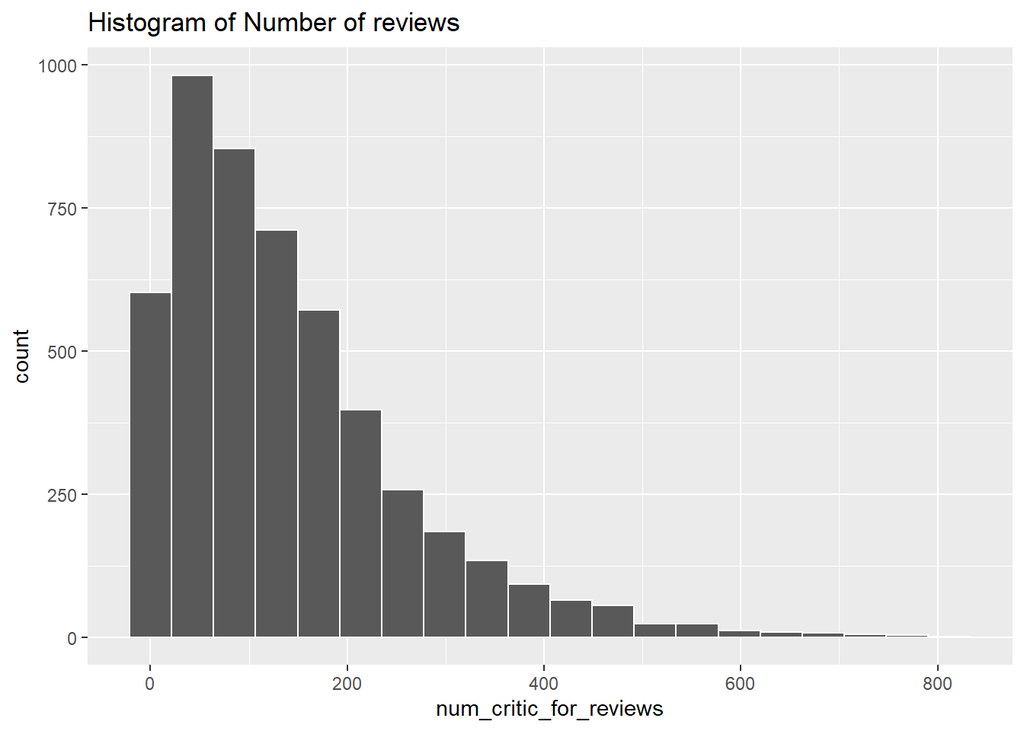

```r
ggplot(aes(x = num_critic_for_reviews), data = movie) + geom_histogram(bins = 20, color = 'white') + ggtitle('Histogram of Number of reviews')
```

```r
summary(movie$num_critic_for_reviews)
```

```
##    Min. 1st Qu.  Median    Mean 3rd Qu.    Max.    NA's
##     1.0    50.0   110.0   140.2   195.0   813.0      50
```

According to this plot most movies have around critic reviews in the range of 50-200

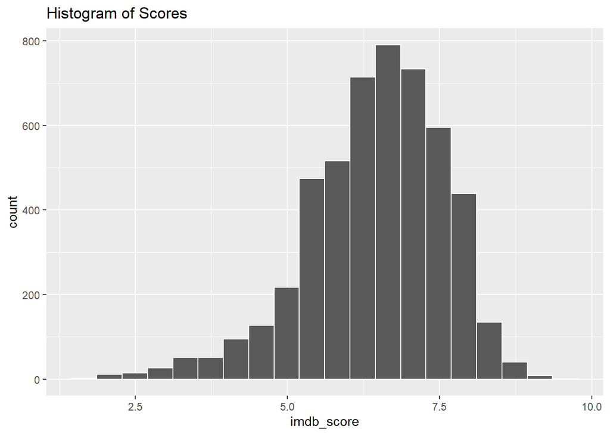

```r
ggplot(aes(x = imdb_score), data = movie) + geom_histogram(bins = 20, color = 'white') + ggtitle('Histogram of Scores')
```

Most frequent IMDB scores for movies are in the range 5.0 to 7.5

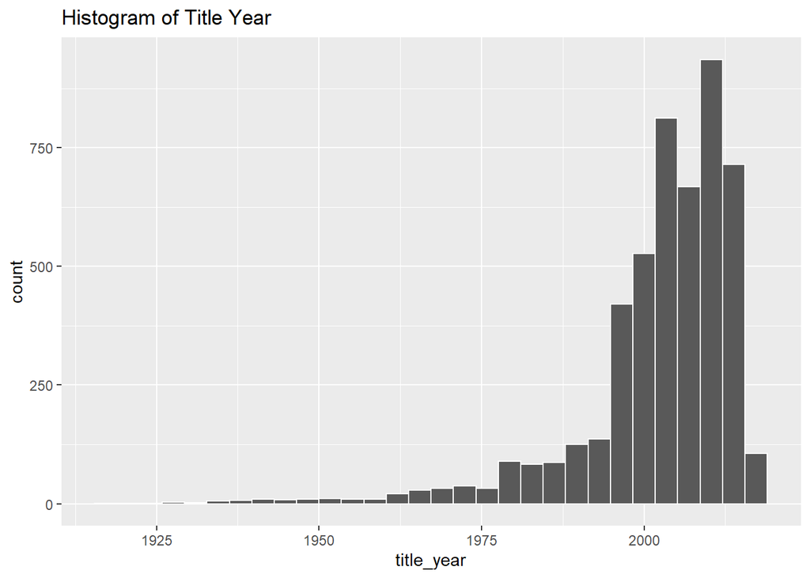

```r
ggplot(aes(x = title_year), data = movie) + geom_histogram(color='white') +
  ggtitle('Histogram of Title Year')
```

This plot tells us the number of movies produced each year. Most of the movies in this dataset are produced after the year 2000

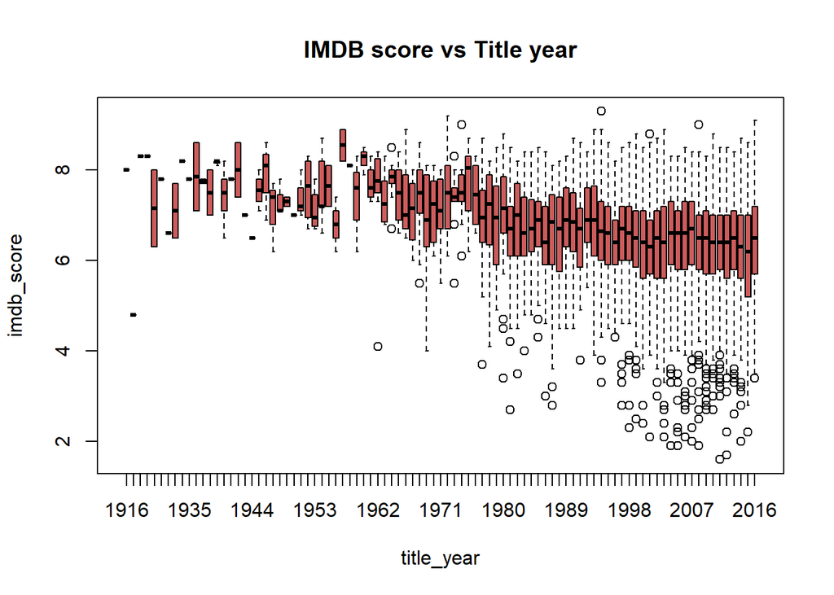

```r
boxplot(imdb_score ~ title_year, data=movie, col='indianred')
title("IMDB score vs Title year")
```

This plot tells us the variation of the IMDB scores over the years. People are ready to give lower scores to movies and this also tells us about the quality of the movies that are being produced. Half a century ago there were only a few players in the movie production market but right now, with the increase of this medium we have seen lots of new producers and directors coming into this market which has led to gradual decrease in the quality of the product with relation to that product.

### Plot of top 10 countries vs number of movies produced

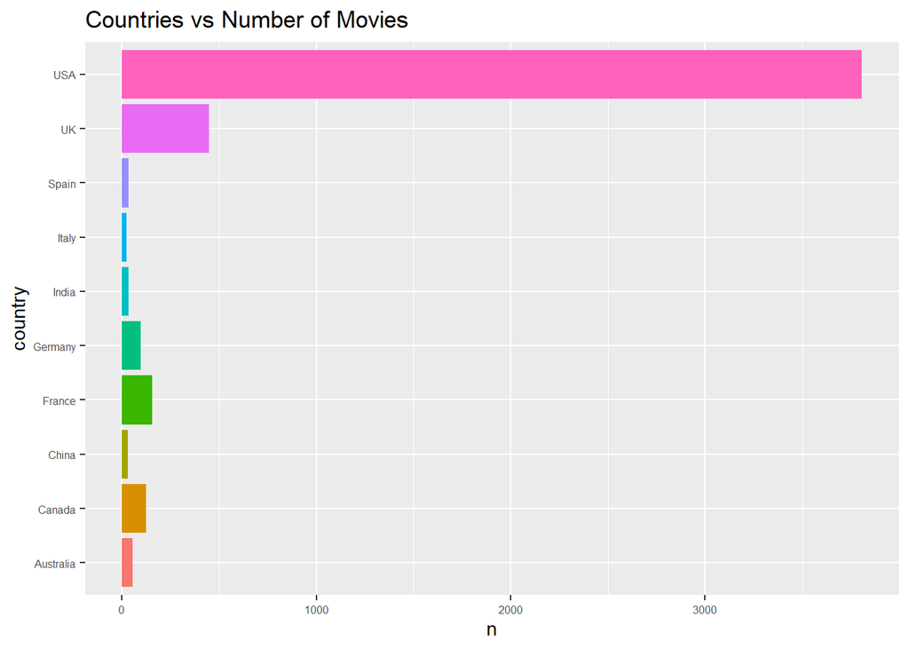

```r
country_group <- group_by(movie, country)
movie_by_country <- summarise(country_group,
                               mean_score = mean(imdb_score),
                               n = n())
aa = movie_by_country[order(-movie_by_country$n), ] %>%
        head(10)
ggplot(aes(x = country, y = n, fill = country), data = aa) + geom_bar(stat = 'identity') + theme(legend.position = "none", axis.text=element_text(size=6)) +
  coord_flip() + ggtitle('Countries vs Number of Movies')
```

The Highest number of movies is produced by the USA

[figure not shown]

```r
ggplot(aes(x = country, y = mean_score, fill = country), data = movie_by_country) + geom_bar(stat = 'identity') + theme(legend.position = "none", axis.text=element_text(size=7)) +
  coord_flip() + ggtitle('Countries vs IMDB Scores')
```

### Data Cleaning

```r
movie$imdb_score <- as.numeric(impute(movie$imdb_score, mean))
movie$num_critic_for_reviews <- as.numeric(impute(movie$num_critic_for_reviews, mean))
movie$duration <- as.numeric(impute(movie$duration, mean))
movie$director_facebook_likes <- as.numeric(impute(movie$director_facebook_likes, mean))
movie$actor_3_facebook_likes <- as.numeric(impute(movie$actor_3_facebook_likes, mean))
movie$actor_1_facebook_likes <- as.numeric(impute(movie$actor_1_facebook_likes, mean))
movie$gross <- as.numeric(impute(movie$gross, mean))
movie$cast_total_facebook_likes <- as.numeric(impute(movie$cast_total_facebook_likes, mean))
movie$facenumber_in_poster <- as.numeric(impute(movie$facenumber_in_poster, mean))
movie$budget <- as.numeric(impute(movie$budget, mean))
movie$title_year <- as.numeric(impute(movie$title_year, median))
movie$actor_2_facebook_likes <- as.numeric(impute(movie$actor_2_facebook_likes, mean))
movie$aspect_ratio <- as.numeric(impute(movie$aspect_ratio, mean))
```

### Separating genres into different columns

```r
movie <- movie %>%
  mutate(genres=gsub("[-]","",genres))
movie = movie %>%
  mutate(row = row_number()) %>%
    separate_rows(genres, sep = '\\|') %>%
      pivot_wider(names_from = genres, values_from = genres, values_fn = function(x) 1, values_fill = 0) %>%
        select(-row)

movie = na.omit(movie)
```

```r
genres = subset(movie, select = c(28:53))

sum = mapply(sum, genres[,]) %>%
        sort(decreasing = TRUE)
```

```r
genre_count = genres %>%
                gather() %>%
                  group_by(key) %>%
                    summarise(value = sum(value==1))
```

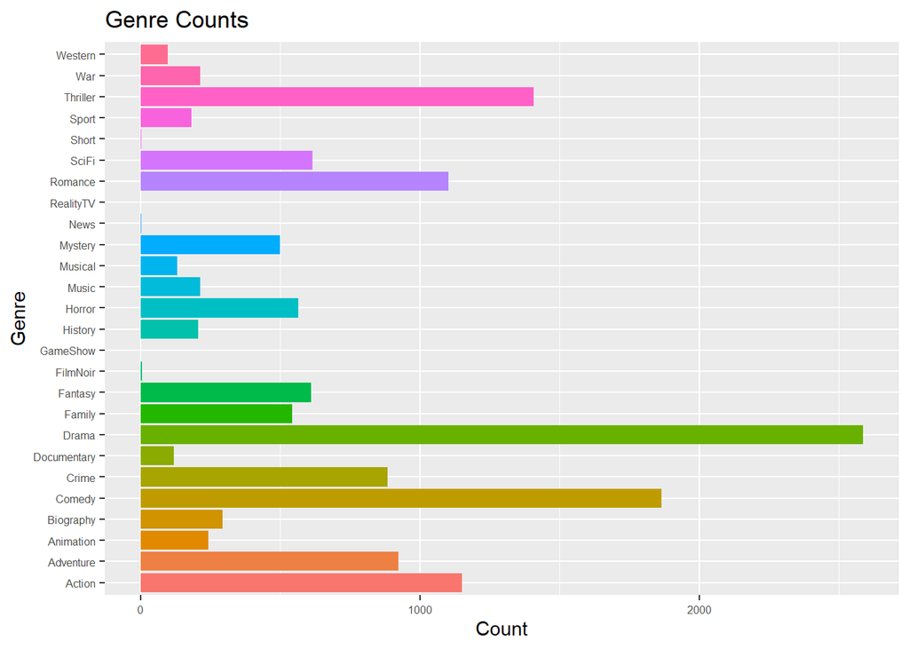

```r
ggplot(genre_count, aes(x=key, y=value, fill=key)) + geom_bar(stat="identity") + theme(legend.position = "none", axis.text=element_text(size=6)) + coord_flip() + ylab("Count") + xlab("Genre") + ggtitle('Genre Counts')
```

Drama is the most produced genre with a count of 2586

### Top 20 highest-rated movie

```r
movie[order(-movie$imdb_score), ] %>%
  select(movie_title) %>%
    head(20)
```

```
## # A tibble: 20 x 1
##    movie_title
##    <chr>
##  1 "The Shawshank RedemptionÂ "
##  2 "The GodfatherÂ "
##  3 "DekalogÂ             "
##  4 "DekalogÂ             "
##  5 "Kickboxer: VengeanceÂ "
##  6 "The Dark KnightÂ "
##  7 "The Godfather: Part IIÂ "
##  8 "FargoÂ             "
##  9 "The Lord of the Rings: The Return of the KingÂ "
## 10 "Schindler's ListÂ "
## 11 "Pulp FictionÂ "
## 12 "The Good, the Bad and the UglyÂ "
## 13 "12 Angry MenÂ "
## 14 "InceptionÂ "
## 15 "The Lord of the Rings: The Fellowship of the RingÂ "
## 16 "DaredevilÂ             "
## 17 "Fight ClubÂ "
## 18 "Forrest GumpÂ "
## 19 "It's Always Sunny in PhiladelphiaÂ             "
## 20 "Star Wars: Episode V - The Empire Strikes BackÂ "
```

### Top 20 lowest-rated movie

```r
movie[order(movie$imdb_score), ] %>%
  select(movie_title) %>%
    head(20)
```

```
## # A tibble: 20 x 1
##    movie_title
##    <chr>
##  1 Justin Bieber: Never Say NeverÂ
##  2 Foodfight!Â
##  3 Disaster MovieÂ
##  4 Superbabies: Baby Geniuses 2Â
##  5 The Helix... LoadedÂ
##  6 United PassionsÂ
##  7 Who's Your Caddy?Â
##  8 From Justin to KellyÂ
##  9 GlitterÂ
## 10 CrossoverÂ
## 11 Son of the MaskÂ
## 12 Snow White: A Deadly SummerÂ
## 13 SubconsciousÂ
## 14 Epic MovieÂ
## 15 Alone in the DarkÂ
## 16 Chairman of the BoardÂ
## 17 Battlefield EarthÂ
## 18 GigliÂ
## 19 Baby GeniusesÂ
## 20 Sunday School MusicalÂ
```

### Average movie duration

```r
mean(movie$duration)
```

```
## [1] 107.3348
```

### Count of movies based on language

```r
lang = movie %>%
        group_by(language) %>%
          summarise(n=n())
lang[order(-lang$n), ]
```

```
## # A tibble: 48 x 2
##    language      n
##    <chr>     <int>
##  1 English    4687
##  2 French       73
##  3 Spanish      40
##  4 Hindi        28
##  5 Mandarin     26
##  6 German       19
##  7 Japanese     18
##  8 Cantonese    11
##  9 Italian      11
## 10 Russian      11
## # ... with 38 more rows
```

### Multiple Linear Regression - Variable Selection

```r
movie_sub <- subset(movie, select = c(3, 4, 5, 8, 9, 13, 15, 22, 27, 28:53, 25))
movie_sub
```

```
## # A tibble: 5,022 x 36
##    num_critic_for_reviews duration director_facebook_~ actor_1_facebook_~  gross
##                     <dbl>    <dbl>               <dbl>              <dbl>  <dbl>
##  1                    723      178                   0               1000 7.61e8
##  2                    302      169                 563              40000 3.09e8
##  3                    602      148                   0              11000 2.00e8
##  4                    813      164               22000              27000 4.48e8
##  5                    462      132                 475                640 7.31e7
##  6                    392      156                   0              24000 3.37e8
##  7                    324      100                  15                799 2.01e8
##  8                    635      141                   0              26000 4.59e8
##  9                    375      153                 282              25000 3.02e8
## 10                    673      183                   0              15000 3.30e8
## # ... with 5,012 more rows, and 31 more variables:
## #   cast_total_facebook_likes <dbl>, facenumber_in_poster <dbl>, budget <dbl>,
## #   movie_facebook_likes <int>, Action <dbl>, Adventure <dbl>, Fantasy <dbl>,
## #   SciFi <dbl>, Thriller <dbl>, Documentary <dbl>, Romance <dbl>,
## #   Animation <dbl>, Comedy <dbl>, Family <dbl>, Musical <dbl>, Mystery <dbl>,
## #   Western <dbl>, Drama <dbl>, History <dbl>, Sport <dbl>, Crime <dbl>,
## #   Horror <dbl>, War <dbl>, Biography <dbl>, Music <dbl>, GameShow <dbl>, ...
```

Only selecting numeric values for the regression model

### Construct the model

```r
set.seed(123)
train_size <- 0.8
train_index <- sample.int(length(movie_sub$imdb_score), length(movie_sub$imdb_score) * train_size)
train_sample <- movie_sub[train_index,]
test_sample <- movie_sub[-train_index,]
```

### Fit the model

```r
fit <- lm(imdb_score ~ num_critic_for_reviews + duration +    director_facebook_likes + actor_1_facebook_likes + gross + cast_total_facebook_likes + facenumber_in_poster + budget + movie_facebook_likes + Action + Adventure + Fantasy +  Thriller + Documentary + Romance + Animation + Comedy + Family + Musical +  Mystery + Western + Drama + History + Sport + Crime + Horror + War + Biography + Music + News + Short, data=train_sample)
summary(fit)
```

```
##
## Call:
## lm(formula = imdb_score ~ num_critic_for_reviews + duration +
##     director_facebook_likes + actor_1_facebook_likes + gross +
##     cast_total_facebook_likes + facenumber_in_poster + budget +
##     movie_facebook_likes + Action + Adventure + Fantasy + Thriller +
##     Documentary + Romance + Animation + Comedy + Family + Musical +
##     Mystery + Western + Drama + History + Sport + Crime + Horror +
##     War + Biography + Music + News + Short, data = train_sample)
##
## Residuals:
##     Min      1Q  Median      3Q     Max
## -5.5361 -0.4912  0.0770  0.5949  3.4765
##
## Coefficients:
##                             Estimate Std. Error t value Pr(>|t|)
## (Intercept)                5.475e+00  8.577e-02  63.836  < 2e-16 ***
## num_critic_for_reviews     2.361e-03  1.836e-04  12.860  < 2e-16 ***
## duration                   4.457e-03  7.051e-04   6.321 2.88e-10 ***
## director_facebook_likes    3.107e-05  5.618e-06   5.530 3.41e-08 ***
## actor_1_facebook_likes     1.406e-05  3.385e-06   4.155 3.32e-05 ***
## gross                      1.978e-09  3.019e-10   6.551 6.45e-11 ***
## cast_total_facebook_likes -1.153e-05  2.908e-06  -3.964 7.51e-05 ***
## facenumber_in_poster      -1.954e-02  7.539e-03  -2.592  0.00958 **
## budget                    -3.100e-10  1.615e-10  -1.920  0.05498 .
## movie_facebook_likes       6.805e-07  1.074e-06   0.634  0.52622
## Action                    -2.542e-01  4.323e-02  -5.880 4.44e-09 ***
## Adventure                 -1.365e-02  4.780e-02  -0.286  0.77525
## Fantasy                   -1.838e-02  5.096e-02  -0.361  0.71838
## Thriller                  -2.649e-01  4.234e-02  -6.255 4.41e-10 ***
## Documentary                9.640e-01  1.085e-01   8.883  < 2e-16 ***
## Romance                   -6.036e-02  3.910e-02  -1.544  0.12277
## Animation                  5.386e-01  8.600e-02   6.263 4.18e-10 ***
## Comedy                    -1.801e-01  3.911e-02  -4.605 4.25e-06 ***
## Family                    -2.655e-01  6.285e-02  -4.224 2.45e-05 ***
## Musical                    1.489e-01  9.575e-02   1.555  0.11999
## Mystery                    9.471e-02  5.408e-02   1.751  0.07999 .
## Western                    1.199e-01  1.138e-01   1.054  0.29182
## Drama                      5.372e-01  3.800e-02  14.138  < 2e-16 ***
## History                    7.109e-02  8.583e-02   0.828  0.40761
## Sport                     -2.935e-02  8.458e-02  -0.347  0.72863
## Crime                      2.082e-01  4.417e-02   4.713 2.52e-06 ***
## Horror                    -4.226e-01  5.622e-02  -7.517 6.91e-14 ***
## War                        2.105e-01  8.071e-02   2.608  0.00915 **
## Biography                  1.580e-01  6.935e-02   2.278  0.02275 *
## Music                     -1.834e-01  7.321e-02  -2.506  0.01226 *
## News                       6.952e-02  5.559e-01   0.125  0.90048
## Short                      8.437e-01  6.742e-01   1.251  0.21085
## ---
## Signif. codes:  0 '***' 0.001 '**' 0.01 '*' 0.05 '.' 0.1 ' ' 1
##
## Residual standard error: 0.9452 on 3985 degrees of freedom
## Multiple R-squared:    0.3,  Adjusted R-squared:  0.2946
## F-statistic: 55.09 on 31 and 3985 DF,  p-value: < 2.2e-16
```

Model with all the variables

```r
fit <- lm(imdb_score ~ num_critic_for_reviews + duration +  director_facebook_likes + actor_1_facebook_likes +  cast_total_facebook_likes + facenumber_in_poster + Action + Thriller + Documentary + Animation + Comedy + Family + Mystery + Drama + Crime + Horror + War + Biography + Music, data=train_sample)
summary(fit)
```

```
##
## Call:
## lm(formula = imdb_score ~ num_critic_for_reviews + duration +
##     director_facebook_likes + actor_1_facebook_likes + cast_total_facebook_likes +
##     facenumber_in_poster + Action + Thriller + Documentary +
##     Animation + Comedy + Family + Mystery + Drama + Crime + Horror +
##     War + Biography + Music, data = train_sample)
##
## Residuals:
##     Min      1Q  Median      3Q     Max
## -5.4419 -0.5039  0.0730  0.6058  3.5303
##
## Coefficients:
##                             Estimate Std. Error t value Pr(>|t|)
## (Intercept)                5.437e+00  8.449e-02  64.356  < 2e-16 ***
## num_critic_for_reviews     2.715e-03  1.376e-04  19.737  < 2e-16 ***
## duration                   5.114e-03  6.851e-04   7.465 1.02e-13 ***
## director_facebook_likes    3.394e-05  5.623e-06   6.035 1.73e-09 ***
## actor_1_facebook_likes     1.021e-05  3.338e-06   3.058 0.002241 **
## cast_total_facebook_likes -7.837e-06  2.855e-06  -2.745 0.006073 **
## facenumber_in_poster      -2.136e-02  7.554e-03  -2.827 0.004719 **
## Action                    -2.264e-01  4.125e-02  -5.487 4.33e-08 ***
## Thriller                  -2.721e-01  4.201e-02  -6.479 1.04e-10 ***
## Documentary                9.796e-01  1.063e-01   9.219  < 2e-16 ***
## Animation                  5.819e-01  8.465e-02   6.874 7.22e-12 ***
## Comedy                    -1.896e-01  3.866e-02  -4.906 9.69e-07 ***
## Family                    -2.086e-01  5.951e-02  -3.505 0.000461 ***
## Mystery                    9.483e-02  5.424e-02   1.748 0.080490 .
## Drama                      5.019e-01  3.705e-02  13.548  < 2e-16 ***
## Crime                      1.978e-01  4.321e-02   4.577 4.87e-06 ***
## Horror                    -4.380e-01  5.508e-02  -7.953 2.35e-15 ***
## War                        2.107e-01  7.733e-02   2.724 0.006470 **
## Biography                  1.570e-01  6.709e-02   2.340 0.019345 *
## Music                     -1.771e-01  7.298e-02  -2.427 0.015268 *
## ---
## Signif. codes:  0 '***' 0.001 '**' 0.01 '*' 0.05 '.' 0.1 ' ' 1
##
## Residual standard error: 0.9501 on 3997 degrees of freedom
## Multiple R-squared:  0.2905, Adjusted R-squared:  0.2871
## F-statistic: 86.14 on 19 and 3997 DF,  p-value: < 2.2e-16
```

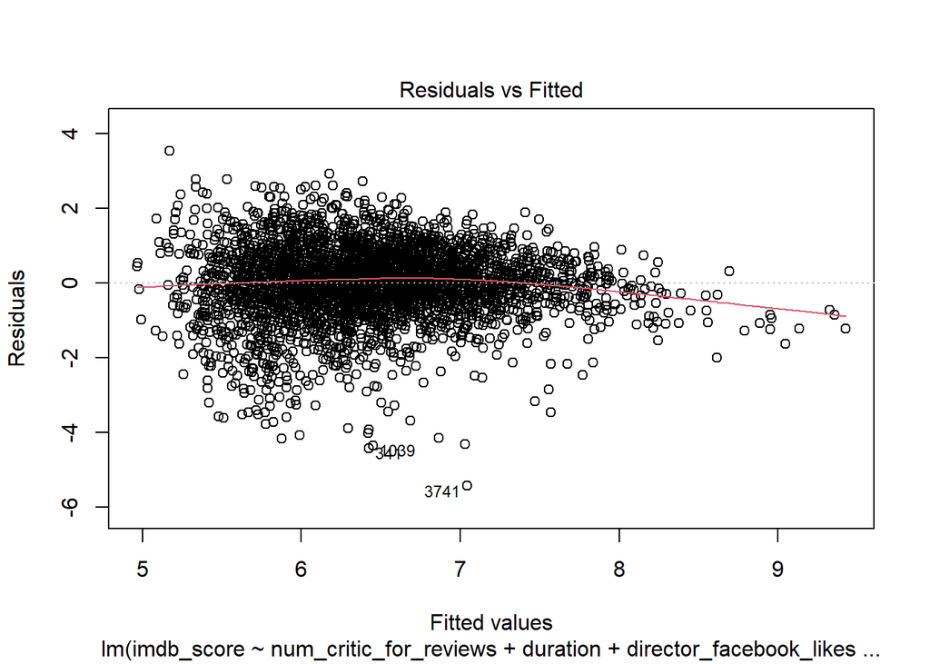

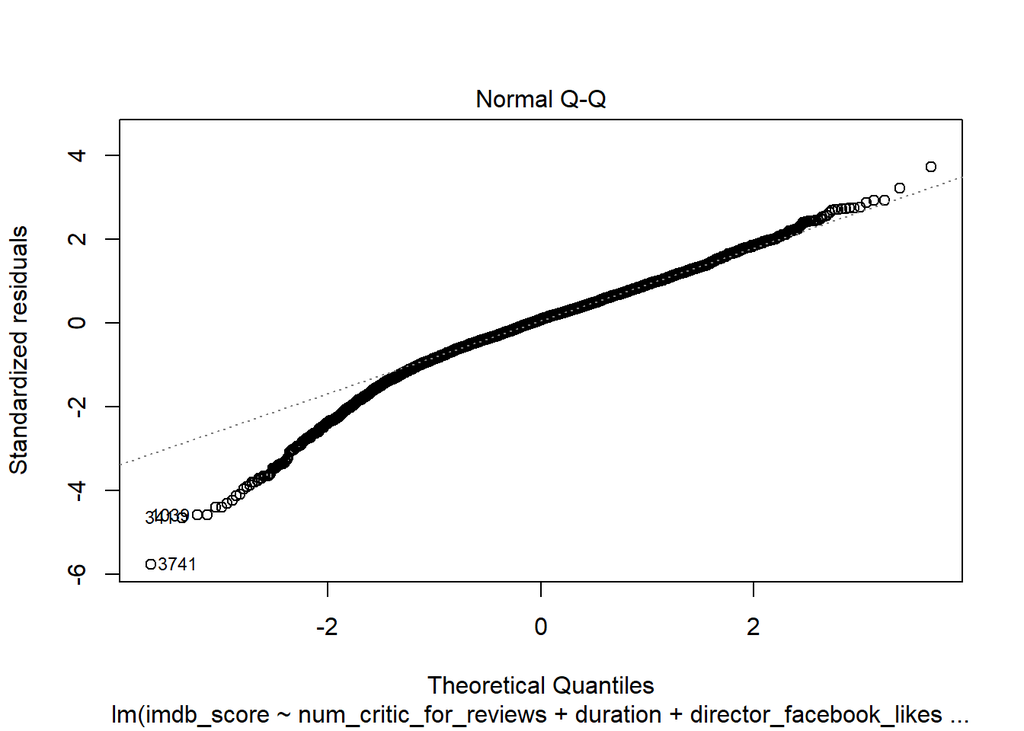

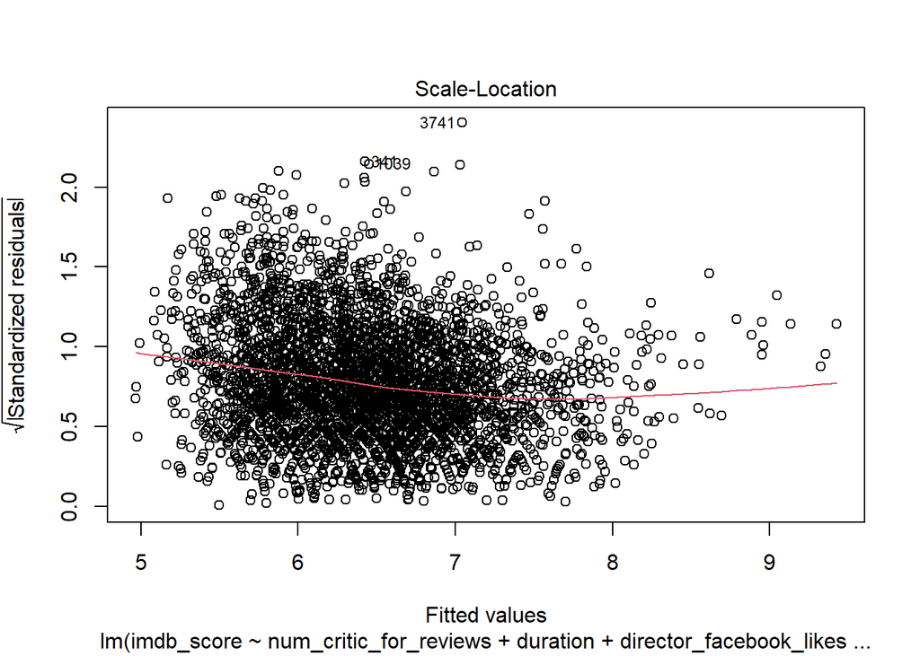

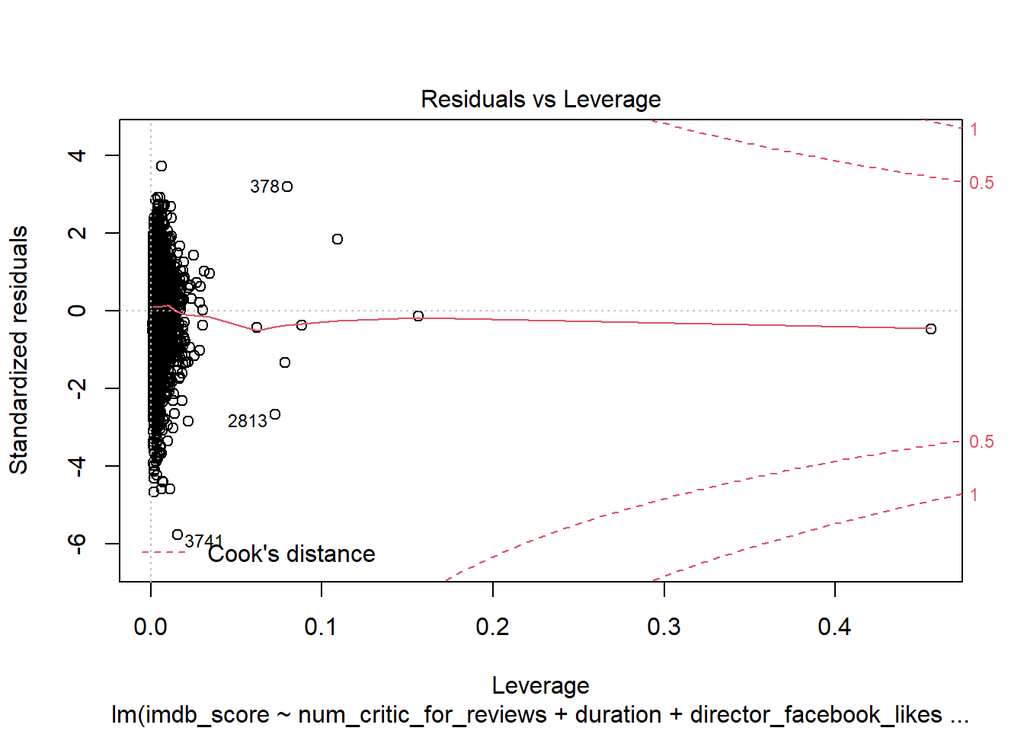

```r
plot(fit)
```

From the residuals vs fitted graph we can see that there are quite a few outliers at the end and overall the dispersion is uneven. From the Normal Q-Q plot we can see that there is a huge deviation at the start.

```r
train_sample$pred_score <- predict(fit, newdata = subset(train_sample, select=c(imdb_score, num_critic_for_reviews, duration, director_facebook_likes, actor_1_facebook_likes, cast_total_facebook_likes, facenumber_in_poster, movie_facebook_likes, Action ,Adventure, Fantasy,Thriller, Documentary ,Romance ,Animation ,Comedy ,Family ,Musical ,Mystery, Western ,Drama ,History ,Sport ,Crime ,Horror,War ,Biography ,Music, News ,Short)))
test_sample$pred_score <- predict(fit, newdata = subset(test_sample, select=c(imdb_score, num_critic_for_reviews, duration, director_facebook_likes, actor_1_facebook_likes, cast_total_facebook_likes, facenumber_in_poster, movie_facebook_likes, Action ,Adventure, Fantasy,Thriller, Documentary ,Romance ,Animation ,Comedy ,Family ,Musical ,Mystery, Western ,Drama ,History ,Sport ,Crime ,Horror,War ,Biography ,Music, News ,Short)))
```

### Evaluating on train set

```r
train_corr <- round(cor(train_sample$pred_score, train_sample$imdb_score), 2)
train_rmse <- round(sqrt(mean((train_sample$pred_score - train_sample$imdb_score)^2)), 2)
train_mae <- round(mean(abs(train_sample$pred_score - train_sample$imdb_score)), 2)
c(train_corr^2, train_rmse, train_mae)
```

```
## [1] 0.2916 0.9500 0.7100
```

The predicted and the actual scores are not highly correlated. RMSE value is high which means the model doesn’t fit the data well MAE is also high which is bad as the predicted imdb score values lie in 0-10 range

### Evaluating on test set

```r
test_rmse <- round(sqrt(mean((test_sample$pred_score - test_sample$imdb_score)^2)), 2)
test_mae <- round(mean(abs(test_sample$pred_score - test_sample$imdb_score)), 2)
c(test_rmse, test_mae)
```

```
## [1] 0.94 0.71
```

Test set also has high RMSE and MAE values

### Decision Tree

```r
library(rpart)
library(rpart.plot)
movie_sub_dectre <- subset(movie, select = c(3, 4, 5, 8, 9, 13, 15, 22, 27, 28:53))
movie_sub_dectre$imdb_cat <- as.numeric(cut2(movie_sub$imdb_score, g=3))

movie_sub_dectre$imdb_cat <- factor(x=movie_sub_dectre$imdb_cat, levels=sort(unique(movie_sub_dectre$imdb_cat)), labels = c("Low", "Medium", "High"))
movie_sub_dectre
```

```
## # A tibble: 5,022 x 36
##    num_critic_for_reviews duration director_facebook_~ actor_1_facebook_~  gross
##                     <dbl>    <dbl>               <dbl>              <dbl>  <dbl>
##  1                    723      178                   0               1000 7.61e8
##  2                    302      169                 563              40000 3.09e8
##  3                    602      148                   0              11000 2.00e8
##  4                    813      164               22000              27000 4.48e8
##  5                    462      132                 475                640 7.31e7
##  6                    392      156                   0              24000 3.37e8
##  7                    324      100                  15                799 2.01e8
##  8                    635      141                   0              26000 4.59e8
##  9                    375      153                 282              25000 3.02e8
## 10                    673      183                   0              15000 3.30e8
## # ... with 5,012 more rows, and 31 more variables:
## #   cast_total_facebook_likes <dbl>, facenumber_in_poster <dbl>, budget <dbl>,
## #   movie_facebook_likes <int>, Action <dbl>, Adventure <dbl>, Fantasy <dbl>,
## #   SciFi <dbl>, Thriller <dbl>, Documentary <dbl>, Romance <dbl>,
## #   Animation <dbl>, Comedy <dbl>, Family <dbl>, Musical <dbl>, Mystery <dbl>,
## #   Western <dbl>, Drama <dbl>, History <dbl>, Sport <dbl>, Crime <dbl>,
## #   Horror <dbl>, War <dbl>, Biography <dbl>, Music <dbl>, GameShow <dbl>, ...
```

Distributing the scores into 3 different categories Low, Medium and High

```r
set.seed(123)
train_size <- 0.8
train_index <- sample.int(length(movie_sub_dectre$imdb_cat), length(movie_sub_dectre$imdb_cat) * train_size)
train_sample <- movie_sub_dectre[train_index,]
test_sample <- movie_sub_dectre[-train_index,]
```

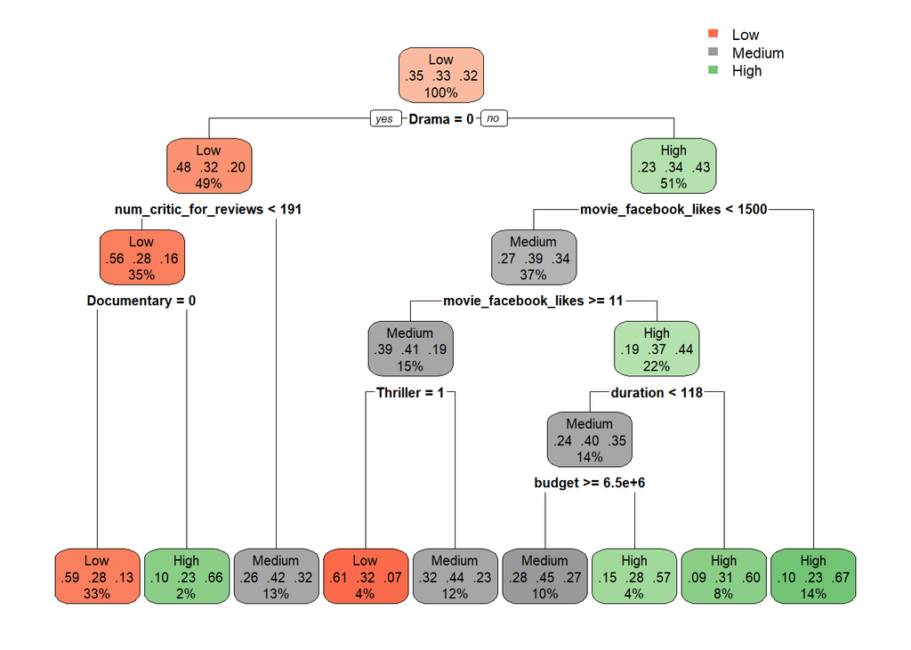

```r
fit <- rpart(imdb_cat ~ num_critic_for_reviews + duration + budget + director_facebook_likes + actor_1_facebook_likes + cast_total_facebook_likes + facenumber_in_poster + movie_facebook_likes + Action + Adventure + Fantasy +  Thriller + Documentary + Romance + Animation + Comedy + Family + Musical +  Mystery + Western + Drama + History + Sport + Crime + Horror + War + Biography + Music + News + Short, data=train_sample, method = 'class')
rpart.plot(fit)
```

```r
predicted <- predict(fit, test_sample, type = 'class')
table_mat <- table(test_sample$imdb_cat, predicted)
table_mat
```

```
##         predicted
##          Low Medium High
##   Low    216     97   45
##   Medium 113    161   78
##   High    39     92  164
```

```r
accuracy_Test <- sum(diag(table_mat)) / sum(table_mat)
print(paste('Accuracy for test', accuracy_Test))
```

```
## [1] "Accuracy for test 0.538308457711443"
```

Accuracy of 54% was achieved on the test data using the decision tree classifier

## Naive bayees using geners only

```r
library(e1071)
genre_sub <- subset(movie_sub_dectre, select = c(10:35, 36))

index <- sample(1 : nrow(genre_sub), round(0.75 * nrow(genre_sub)))

train_cl <- genre_sub[index, ]
test_cl <- genre_sub[-index, ]

set.seed(120)
classifier_cl <- naiveBayes(imdb_cat ~ ., data = train_cl)
classifier_cl
```

```
##
## Naive Bayes Classifier for Discrete Predictors
##
## Call:
## naiveBayes.default(x = X, y = Y, laplace = laplace)
##
## A-priori probabilities:
## Y
##       Low    Medium      High
## 0.3467870 0.3380244 0.3151885
##
## Conditional probabilities:
##         Action
## Y             [,1]      [,2]
##   Low    0.2993874 0.4581652
##   Medium 0.2380204 0.4260391
##   High   0.1600674 0.3668231
##
##         Adventure
## Y             [,1]      [,2]
##   Low    0.2021440 0.4017529
##   Medium 0.1696779 0.3754971
##   High   0.1794440 0.3838854
##
##         Fantasy
## Y             [,1]      [,2]
##   Low    0.1493109 0.3565312
##   Medium 0.1194030 0.3243895
##   High   0.1002527 0.3004633
##
##         SciFi
## Y              [,1]      [,2]
##   Low    0.15696784 0.3639098
##   Medium 0.11783189 0.3225357
##   High   0.09351306 0.2912728
##
##         Thriller
## Y             [,1]      [,2]
##   Low    0.3147014 0.4645747
##   Medium 0.3079340 0.4618205
```

[output cut: 112 more lines]

```
##   Low    0.00000000 0.00000000
##   Medium 0.00000000 0.00000000
##   High   0.00084246 0.02902516
##
##         Short
## Y               [,1]       [,2]
##   Low    0.000000000 0.00000000
##   Medium 0.001571092 0.03962142
##   High   0.000842460 0.02902516
##
##         FilmNoir
## Y              [,1]       [,2]
##   Low    0.00000000 0.00000000
##   Medium 0.00000000 0.00000000
##   High   0.00252738 0.05023065
```

```r
y_pred <- predict(classifier_cl, newdata = test_cl)

cm <- table(test_cl$imdb_cat, y_pred)
cm
```

```
##         y_pred
##          Low Medium High
##   Low    181    261   11
##   Medium 103    291   14
##   High    86    265   44
```

```r
print(paste("Accuracy", sum(diag(cm)) / sum(cm)))
```

```
## [1] "Accuracy 0.410828025477707"
```

Accuracy of 41% was achieved with Naive bayees classifier

### KNN

```r
library(caTools)
library(class)
```

```r
set.seed(123)
train_size <- 0.8
train_index <- sample.int(length(movie_sub_dectre$imdb_cat), length(movie_sub_dectre$imdb_cat) * train_size)
train_sample <- movie_sub_dectre[train_index,]
test_sample <- movie_sub_dectre[-train_index,]

train_sample <- na.omit(train_sample)
test_sample <- na.omit(test_sample)

train_cl <- train_sample[, 1:35]
test_cl <- test_sample[, 1:35]

classifier_knn <- knn(train = train_cl,
                      test = test_cl,
                      cl = train_sample$imdb_cat,
                      k =100)
cm <- table(test_sample$imdb_cat, classifier_knn)
cm
```

```
##         classifier_knn
##          Low Medium High
##   Low    172    107   79
##   Medium 140    127   85
##   High    93     81  121
```

```r
misClassError <- mean(classifier_knn != test_sample$imdb_cat)
print(paste('Accuracy =', 1-misClassError))
```

```
## [1] "Accuracy = 0.417910447761194"
```

Accuracy of 42% was achieved with KNN classifier

## Neural networks

```r
library(neuralnet)
movie_sub_dectre$imdb_num <- factor(x=movie_sub_dectre$imdb_cat, levels=sort(unique(movie_sub_dectre$imdb_cat)), labels = c(1,2,3))
movie_sub_dectre$imdb_num = as.numeric(movie_sub_dectre$imdb_num)

movie_idk = select(movie_sub_dectre, -c("imdb_cat"))
```

```r
index <- sample(1 : nrow(movie_idk),
                round(0.75 * nrow(movie_idk)))
maxs <- apply(movie_idk, 2, max)
mins <- apply(movie_idk, 2, min)
scaled <- as.data.frame(scale(movie_idk,
                              center = mins,
                              scale = maxs - mins))
aa = movie_idk[index, ]
ab = movie_idk[-index, ]

train_ <- scaled[index, ]
test_ <- scaled[-index, ]

train_$imdb_num = as.numeric(as.factor(aa$imdb_num))
test_$imdb_num = as.numeric(as.factor(ab$imdb_num))
```

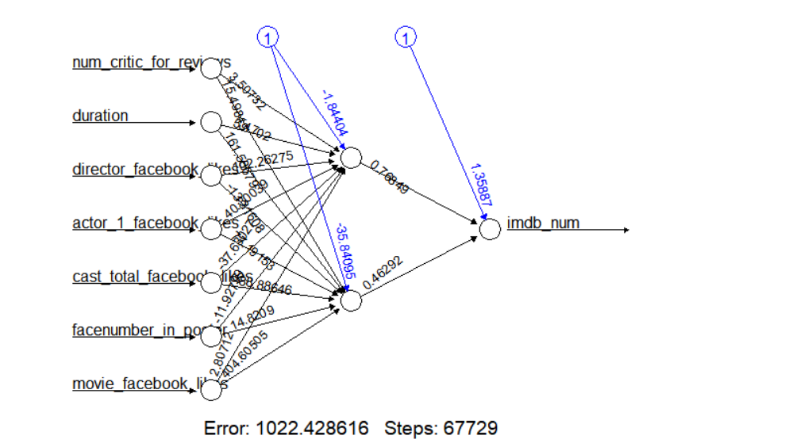

```r
NN = neuralnet(imdb_num ~ num_critic_for_reviews + duration + director_facebook_likes + actor_1_facebook_likes + cast_total_facebook_likes + facenumber_in_poster + movie_facebook_likes, data=train_, hidden = 2)
plot(NN)
```

```r
d = round(NN$net.result[[1]])
cm = table(d, train_$imdb_num)
cm
```

```
##
## d      1    2    3
##   1  118   37   17
##   2 1172 1147  945
##   3   32   81  217
```

```r
print(paste("Accuracy", sum(diag(cm)) / sum(cm)))
```

```
## [1] "Accuracy 0.3935209771641"
```

### Conclusion

We were able to successfully analyze and interpret the IMDB movie dataset. With the help of some well written research papers, we were able to work upon interpreting the results on a higher level. We used multiple models to predict the scores which includes KNN, Neural networks, Regression, Naive Bayees, Decision trees. We also did exploratory analysis on the dataset which helped us come to conclusion on the overall trends of the movie market.